# IEFCIC R Notebook 2

Éste es un [R Markdown](http://rmarkdown.rstudio.com) Notebook. Cuando ejecutes el código contenido, los resultados aparecerán debajo del código.

Los archivos que se van a usar fueron descargados de datos.gov.co. Luego fueron extraídos de forma local en formato .txt y .sav.

En el [vídeo](https://www.youtube.com/watch?v=6ULCP7NsITY) se explica paso a paso la obtención de datos, y en [este vídeo](https://www.youtube.com/watch?v=5wCkW6y36DA&t=8s) se muestran algunas ideas de análisis exploratorio básico.

1. Cargando el set de datos (que puede descargar también desde [aquí](https://github.com/oscarvilla/youtube/tree/master/iefcic)) Y revisamos el encabezado solo para estar seguros.

```r
library(haven)
setwd("./")
df <- read_sav("./IEFIC_2015.sav")
head(df)
```

| ANIO | CLASE | DIRECTORIO_GEIH | FEX_C | INGRESO_COMPLETO | INGTOTOB | LLAVE_PER_GEIH | ORDEN | PERIODO | SECUENCIA_P | P10 | P1136 | P1237 | P1239 | P1421 | P2168 | P2211 | P232 | P241 | P242 | P2424 | P2439 | P2447 | P2461 | P2462 | P2464 | P2465 | P2466 | P2469 | P2470 | … |
| --- | --- | --- | --- | --- | --- | --- | --- | --- | --- | --- | --- | --- | --- | --- | --- | --- | --- | --- | --- | --- | --- | --- | --- | --- | --- | --- | --- | --- | --- | --- |
| 2015 | 1 | 3641876 | 230.5553 | 1 | 1242080 | 201501364187611 | 1 | 1 | 1 | 100 | NaN | NaN | 2 | NaN | NaN | NaN | 2 | 85 | 1 |  | 1 | 1987 | 1.0e+08 | 2 | NaN | NaN | 2 | NaN | NaN | … |
| 2015 | 1 | 3641876 | 230.5553 | 1 | 975000 | 201501364187612 | 2 | 1 | 1 | 511 | 3e+06 | NaN | 2 | NaN | NaN | NaN | 2 | 55 | 3 |  | 1 | 1987 | 1.0e+08 | 2 | NaN | NaN | 2 | NaN | NaN | … |
| 2015 | 1 | 3641879 | 255.8069 | 1 | 792080 | 201501364187911 | 1 | 1 | 1 | 409 | NaN | NaN | 2 | NaN | NaN | NaN | 3 | 68 | 1 |  | 1 | 1982 | 5.0e+07 | 2 | NaN | NaN | 2 | NaN | NaN | … |
| 2015 | 1 | 3641879 | 255.8069 | 1 | 700000 | 201501364187912 | 2 | 1 | 1 | 602 | NaN | NaN | NaN | NaN | NaN | NaN | 3 | 27 | 3 |  | 1 | 1982 | 5.0e+07 | 2 | NaN | NaN | 2 | NaN | NaN | … |
| 2015 | 1 | 3641879 | 255.8069 | 1 | 1958867 | 201501364187913 | 3 | 1 | 1 | 602 | NaN | NaN | 2 | NaN | NaN | NaN | 3 | 33 | 3 |  | 1 | 1982 | 5.0e+07 | 2 | NaN | NaN | 2 | NaN | NaN | … |
| 2015 | 1 | 3641880 | 201.7251 | 1 | 1600000 | 201501364188011 | 1 | 1 | 1 | 409 | NaN | 9 | 1 | 9 | NaN | NaN | 3 | 63 | 1 |  | 1 | 1981 | 4.5e+07 | 2 | NaN | NaN | 2 | NaN | NaN | … |

2. Extrayendo las variables por subgrupos. Así podremos explorarlas para quedarnos en cada caso solamente con las que son de nuestro interés.

```r
## Dejo comentado los subconjuntos que no voy a usar por ahora
## dingresos <- df[, c(5:6)]
## dinstfinan <- df[, c(12:15)]
## delectrodom <- df[, c(43:54)]
## dgastoshog <- df[, c(55:68)]
## ddistinghog <- df[, c(69:95)]
## dmaqyequ <- df[, c(115:118)]
ddeudanohipotecaria <- df[, c(129:179)]
## dendeud <- df[, c(203:209)]
## dnegocio <- df[, c(210:214)]
## dcrednegocio <- df[, c(215:221)]
## dcredvehic <- df[, c(224:232)]
## dsex <- df[, 233]
## dcreditoytarj <- df[, c(234:255)]
```

3. Vamos a enfocarnos en el apartado “F. Deudas no hipotecarias”. Tenemos que limpiar el set de datos: convertimos todos los NaN a ceros (0), removemos columnas innecesarias y convertimos algunas a factor.

```r
## Creamos la función que ajusta el formato del set de datos
limpia <- function(x){
        x <- sapply(x, FUN = function(x) {x <- as.numeric(x)})
        x[x == "NaN"] <- 0 ## Convertir todos los NaN a cero
        x[is.na(x)] <- 0
        return(x)
}
dt <- as.data.frame(limpia(ddeudanohipotecaria))
dt <- dt[, -c(2, 9, 18, 25, 32, 39, 47)] ## Columnas de ceros (son realmente encabezados de categorías)
dt <- dt[, -c(42:44)] ## Total de endeudamiento con capital e intereses
dt <- dt[dt$P2540 != 0,] ## Dejemos por fuera de la muestra a quienes no tienen tarjeta de crédito
cols <- c("P2540", "P2548", "P2584", "P2595", "P2602", "P2630", "P2633", "P2638", "P2692", "P2694",
          "P2695", "P2731", "P2734")
dt[cols] <- lapply(dt[cols], factor)
l <- as.logical(lapply(dt, class)=="numeric")
dtCorr <- dt[, l]
```

4. Visualización de los datos: El analisis de los datos puede agilizarse gracias a la visualización de los mismos. Primero veamos todas las correlaciones de las variables entre sí, para luego pasar a ver la correlación con la variable que hemos definido como dependiente: endeudamiento total.

4.1. Correlaciones de todas las variables que no son factor entre sí:

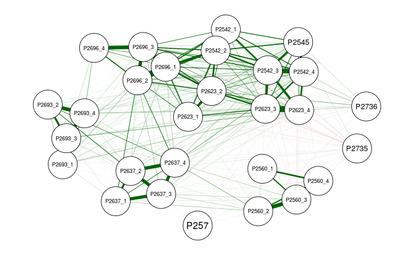

```r
library(qgraph)
qgraph(cor(dtCorr), shape="circle", posCol="darkgreen", negCol="darkred", layout="spring", vsize=8)
```

Tenemos: En primera instancia el hecho de que casi todas las correlaciones son positivas (verdes, mientras más gruesas mayor); lo cual parece indicar que mientras más endeudado se está más se tiende a endeudarse.

Sin embargo hay variables que tienen correlaciones negativas (rojas, mientras más delgadas menor), si bien poco significativas: la P2735 que se refiere al número total de hogares en la vivienda con las P2623_; a mayor número de hogares, el endeudamiento en créditos de libre inversión disminuye. La P2560_3 con las P2623_: Cuando aumentan las cuotas de las compraventas, disminuye las de crédito de libre inversión. Como si los créditos de libre inversión se vieran disminuidos cuando aumenta el número de hogares en la vivienda y cuando se recurre a las compraventas. Esto sin que entre el número de hogares en la vivienda y las cuotas en las compraventas haya correlación.

También se revela que el capital e intereses de las tarjetas de crédito tiene alta correlación positiva con el capital e intereses de los créditos de libre inversión.

Pero no se revela una variable determinante de la variable dependiente.

4.2. Correlaciones de las variables con la variable definida como dependiente:

```r
corr <- as.data.frame(cor(dtCorr)[, ncol(dtCorr)])
names(corr) <- "coefcorr"
corr
```

|  | coefcorr |
| --- | --- |
| P2542_1 | 0.0148031935 |
| P2542_2 | 0.0306515836 |
| P2542_3 | 0.0216361506 |
| P2542_4 | 0.0202023548 |
| P2545 | 0.0171790058 |
| P2560_1 | -0.0005626009 |
| P2560_2 | 0.0077892026 |
| P2560_3 | 0.0023033356 |
| P2560_4 | -0.0001633990 |
| P2579 | -0.0017516633 |

[output cut: 18 more lines]

Algunas variables tiene correlaciones fuertes entre sí, pero no con la variable dependiente

5. Aventuremos la construcción de un modelo con regresiones lineales:

5.1. Primero tomemos a todas las variables:

```r
model1 <- lm(P2736_1 ~., data = dt)
summary(model1)
```

```
Call:
lm(formula = P2736_1 ~ ., data = dt)

Residuals:
    Min      1Q  Median      3Q     Max
-228240     181     271     271 1563151

Coefficients: (4 not defined because of singularities)
              Estimate Std. Error t value Pr(>|t|)
(Intercept)  2.046e+02  2.715e+04   0.008  0.99399
P25402      -1.251e+01  5.596e+02  -0.022  0.98217
P2542_1      1.608e-04  2.000e-03   0.080  0.93593
P2542_2      2.903e-02  1.069e-02   2.714  0.00665 **
P2542_3     -1.977e-04  6.933e-04  -0.285  0.77556
P2542_4      3.643e-05  6.062e-05   0.601  0.54788
P2545       -2.096e+01  3.335e+01  -0.628  0.52978
P25481       3.021e+01  3.924e+04   0.001  0.99939
P25482       1.251e+01  3.838e+04   0.000  0.99974
P2560_1      8.903e-03  6.771e-02   0.131  0.89539
P2560_2      2.497e-02  6.218e-02   0.402  0.68804
P2560_3      1.602e-02  3.724e-02   0.430  0.66709
P2560_4     -1.585e-04  1.065e-03  -0.149  0.88171
P2579        4.494e-06  6.749e-04   0.007  0.99469
P25841      -1.807e+02  2.714e+04  -0.007  0.99469
P25842      -2.713e+02  2.714e+04  -0.010  0.99202
P25848       3.136e-09  3.133e+04   0.000  1.00000
P25849       4.148e+02  2.901e+04   0.014  0.98859
P25951      -4.040e+03  9.826e+03  -0.411  0.68100
P25952       1.345e+03  1.016e+04   0.132  0.89462
P26021      -2.572e+02  1.748e+03  -0.147  0.88298
P26022              NA         NA      NA       NA
P2623_1      2.744e-03  2.135e-03   1.285  0.19871
P2623_2      3.861e-02  9.387e-03   4.113 3.92e-05 ***
P2623_3     -1.019e-03  1.096e-03  -0.930  0.35246
P2623_4     -1.128e-05  2.473e-05  -0.456  0.64820
P26301       9.999e+02  1.918e+03   0.521  0.60221
P26302       5.303e+02  2.423e+03   0.219  0.82675
P26308      -1.050e+03  9.785e+03  -0.107  0.91452
P26309       1.919e+05  1.068e+04  17.965  < 2e-16 ***
P26331      -4.164e+03  3.876e+04  -0.107  0.91445
```

[output cut: 22 more lines]

```
P2696_2      4.396e-02  4.618e-02   0.952  0.34118
P2696_3     -4.432e-03  4.122e-03  -1.075  0.28231
P2696_4      3.912e-05  1.219e-04   0.321  0.74837
P27311       3.740e+04  3.081e+03  12.140  < 2e-16 ***
P27312       1.919e+04  4.105e+03   4.676 2.95e-06 ***
P27319       6.594e+02  1.594e+04   0.041  0.96700
P27341       2.155e+03  1.698e+03   1.269  0.20440
P27342              NA         NA      NA       NA
P2735       -2.046e+02  9.257e+02  -0.221  0.82510
---
Signif. codes:  0 ‘***’ 0.001 ‘**’ 0.01 ‘*’ 0.05 ‘.’ 0.1 ‘ ’ 1

Residual standard error: 27130 on 17860 degrees of freedom
Multiple R-squared:  0.08418,   Adjusted R-squared:  0.08126
F-statistic:  28.8 on 57 and 17860 DF,  p-value: < 2.2e-16
```

5.2. Entonces intentemos un nuevo modelo con las variables que se mostraron significativas, las marcadas con asteriscos, pero teniendo en cuenta que algunas luego le restan precisión al modelo. En este caso, tener más variables no necesariamente implica que el modelo sea mejor. Un punto de partida puede ser tomar las variables que mayor correlación (positiva o negativa) tienen con la variable dependiente y a la vez las que menor correlación tienen con estas primeras. Luego, es necesario ir haciendo ajustes y probando.

```r
model2 <- lm(P2736_1 ~ P2542_2 + P2623_2, data = dt)
summary(model2)
```

```
Call:
lm(formula = P2736_1 ~ P2542_2 + P2623_2, data = dt)

Residuals:
    Min      1Q  Median      3Q     Max
 -47294   -1322   -1322   -1322 1598675

Coefficients:
             Estimate Std. Error t value Pr(>|t|)
(Intercept) 1.322e+03  2.127e+02   6.216 5.21e-10 ***
P2542_2     2.797e-02  9.411e-03   2.972  0.00297 **
P2623_2     4.501e-02  9.026e-03   4.987 6.18e-07 ***
---
Signif. codes:  0 ‘***’ 0.001 ‘**’ 0.01 ‘*’ 0.05 ‘.’ 0.1 ‘ ’ 1

Residual standard error: 28280 on 17915 degrees of freedom
Multiple R-squared:  0.002325,  Adjusted R-squared:  0.002213
F-statistic: 20.87 on 2 and 17915 DF,  p-value: 8.825e-10
```

5.3. Grtafiquemos los resultados del modelo obtenido:

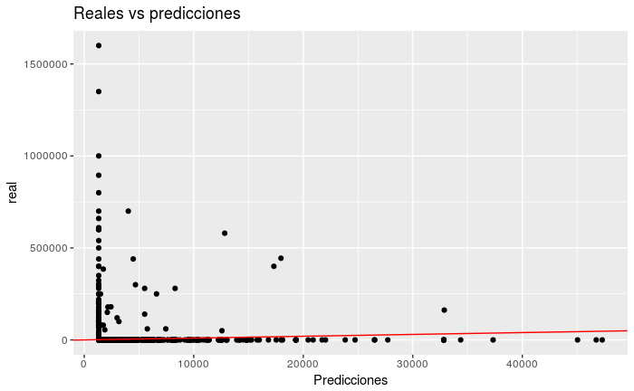

```r
pred <- predict(model2, newdata = as.data.frame(dt[, 1:40]))
p <- data.frame(pred = pred, real = dt[, 41], residuos = (pred - dt[, 41]))
library(ggplot2)
ggplot(p, aes(x=pred, y=real)) + geom_point() + geom_abline(intercept = 0, slope = 1, col="red") + ggtitle("Reales vs predicciones") + xlab("Predicciones")
```

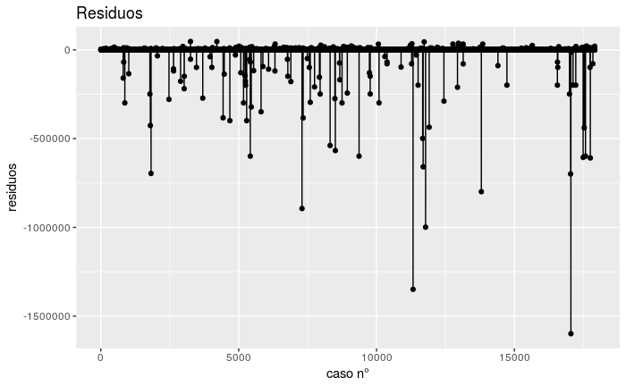

```r
ggplot(p, aes(x=1:nrow(p), y=residuos)) + geom_point() + geom_line() + ggtitle("Residuos") + xlab("caso n°")
```

6. Conclusiones y líneas a seguir: Es un modelo que en tanto que predictor está muy lejos de ser bueno, a pesar de que su error standard promedio es de 2906.5987482, dado que los datos tienen una distribución no normal, desbalanceada, en la que la mayoría de los casos son (17195) son cero, y solamente 723 son distintos a cero. Esto hace que el modelo lineal hago lo posible por reducir el error standard promedio (el promedio de la raíz cuadrada del cuadrado de la diferencia), produciendo errores o residuos muy altos en algunas partes.

Sin embargo, en tanto que análisis exploratorio nos permite identificar variables sobre las cuales se debe hacer un estudio para verificar su relevancia en el estado total de endeudamiento.

Es así que de 51 variables nos quedamos con 2, por ahora:

- P2542_2: Lo que paga como intereses mensualmente por tarjetas de crédito (en importancia, por encima del capital o el valor de capital más intereses).
- P2623_2: Lo que paga como intereses por préstamos de libre inversión (en importancia, por encima del capital o el valor de capital más intereses).

Arriesgando una interpretación, puede decirse que es más determinante la tasa de interés que el capital; es decir, que variando los capitales adeudados, es determinante la tasa de interés. Y uno tendría que preguntarse qué lleva a que las personas tomen créditos con tasas más altas ¿la urgencia? ¿la falta de conocimiento? ¿otra?

Por otro lado, los créditos de libre inversión y las tarjetas de crédito, puede que sean los que mayor afectación tiene sobre las deudas porque sus montos son más altos que los de las casas de empeño, las tiendas y los gota a gota; además del hecho de la declarabilidad de los distintos tipos de crédito.